# DATA605_w12_Regression Analysis

David Simbandumwe

# Overview

The attached who.csv dataset contains real-world data from 2008. The variables included follow. Country: name of the country LifeExp: average life expectancy for the country in years InfantSurvival: proportion of those surviving to one year or more Under5Survival: proportion of those surviving to five years or more TBFree: proportion of the population without TB. PropMD: proportion of the population who are MDs PropRN: proportion of the population who are RNs PersExp: mean personal expenditures on healthcare in US dollars at average exchange rate GovtExp: mean government expenditures per capita on healthcare, US dollars at average exchange rate TotExp: sum of personal and government expenditures.

```r
df <- read_csv('Homework/data/xid-528551256_1.csv')
```

# Question 1

Provide a scatterplot of LifeExp~TotExp, and run simple linear regression. Do not transform the variables. Provide and interpret the F statistics, R^2, standard error,and p-values only. Discuss whether the assumptions of simple linear regression met.

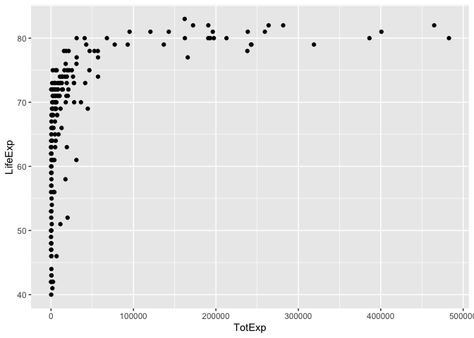

```r
ggplot(df, aes(x=TotExp, y=LifeExp)) + geom_point()
```

```r
df_lm.1 <- lm(data = df, LifeExp ~ TotExp)
s_lm <- summary(df_lm.1)
s_lm
```

```
##
## Call:
## lm(formula = LifeExp ~ TotExp, data = df)
##
## Residuals:
##     Min      1Q  Median      3Q     Max
## -24.764  -4.778   3.154   7.116  13.292
##
## Coefficients:
##                 Estimate   Std. Error t value             Pr(>|t|)
## (Intercept) 64.753374534  0.753536611  85.933 < 0.0000000000000002 ***
## TotExp       0.000062970  0.000007795   8.079   0.0000000000000771 ***
## ---
## Signif. codes:  0 '***' 0.001 '**' 0.01 '*' 0.05 '.' 0.1 ' ' 1
##
## Residual standard error: 9.371 on 188 degrees of freedom
## Multiple R-squared:  0.2577, Adjusted R-squared:  0.2537
## F-statistic: 65.26 on 1 and 188 DF,  p-value: 0.00000000000007714
```

Even thought the model is statistically significant as a whole it has limited predictive power.

# Question 2

Raise life expectancy to the 4.6 power (i.e., LifeExp^4.6). Raise total expenditures to the 0.06 power (nearly a log transform, TotExp^.06). Plot LifeExp^4.6 as a function of TotExp^.06, and r re-run the simple regression model using the transformed variables. Provide and interpret the F statistics, R^2, standard error, and p-values. Which model is “better?”

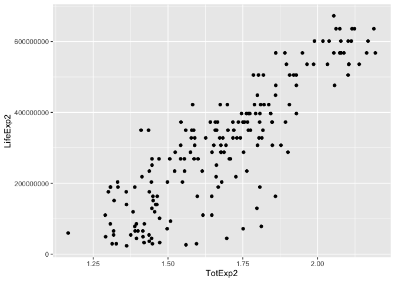

```r
df$LifeExp2 <- df$LifeExp^4.6
df$TotExp2 <- df$TotExp^0.06

ggplot(df, aes(x=TotExp2, y=LifeExp2)) + geom_point()
```

```r
df_lm.2 <- lm(data = df, LifeExp2 ~ TotExp2)
s_lm <- summary(df_lm.2)
s_lm
```

```
##
## Call:
## lm(formula = LifeExp2 ~ TotExp2, data = df)
##
## Residuals:
##        Min         1Q     Median         3Q        Max
## -308616089  -53978977   13697187   59139231  211951764
##
## Coefficients:
##               Estimate Std. Error t value            Pr(>|t|)
## (Intercept) -736527910   46817945  -15.73 <0.0000000000000002 ***
## TotExp2      620060216   27518940   22.53 <0.0000000000000002 ***
## ---
## Signif. codes:  0 '***' 0.001 '**' 0.01 '*' 0.05 '.' 0.1 ' ' 1
##
## Residual standard error: 90490000 on 188 degrees of freedom
## Multiple R-squared:  0.7298, Adjusted R-squared:  0.7283
## F-statistic: 507.7 on 1 and 188 DF,  p-value: < 0.00000000000000022
```

The changes to the model have significantly increased the predictive power of the model while maintaining its statistical significance.

# Question 3

Using the results from 3, forecast life expectancy when TotExp^.06 =1.5. Then forecast life expectancy when TotExp^.06=2.5.

```r
pred_df1 <- data.frame(TotExp2 = c(1.5,2.5))
pred_df1$LifeExp2 <- predict(df_lm.2,pred_df1)
pred_df1
```

```
##   TotExp2  LifeExp2
## 1     1.5 193562414
## 2     2.5 813622630
```

# Question 4

Build the following multiple regression model and interpret the F Statistics, R^2, standard error, and p-values. How good is the model?

$$LifeExp = b0+b1 x PropMd + b2 x TotExp
+b3 x PropMD x TotExp$$

```r
df_lm.3 <- lm(data = df, LifeExp ~ PropMD + TotExp + PropMD * TotExp)
s_lm <- summary(df_lm.3)
s_lm
```

```
##
## Call:
## lm(formula = LifeExp ~ PropMD + TotExp + PropMD * TotExp, data = df)
##
## Residuals:
##     Min      1Q  Median      3Q     Max
## -27.320  -4.132   2.098   6.540  13.074
##
## Coefficients:
##                     Estimate     Std. Error t value             Pr(>|t|)
## (Intercept)     62.772703255    0.795605238  78.899 < 0.0000000000000002 ***
## PropMD        1497.493952519  278.816879652   5.371   0.0000002320602774 ***
## TotExp           0.000072333    0.000008982   8.053   0.0000000000000939 ***
## PropMD:TotExp   -0.006025686    0.001472357  -4.093   0.0000635273294941 ***
## ---
## Signif. codes:  0 '***' 0.001 '**' 0.01 '*' 0.05 '.' 0.1 ' ' 1
##
## Residual standard error: 8.765 on 186 degrees of freedom
## Multiple R-squared:  0.3574, Adjusted R-squared:  0.3471
## F-statistic: 34.49 on 3 and 186 DF,  p-value: < 0.00000000000000022
```

# Question 5

```r
pred_df2 <- data.frame(PropMD = .03, TotExp = 15)
pred_df2$LifeExp <- predict(df_lm.3,pred_df2)
pred_df2
```

```
##   PropMD TotExp  LifeExp
## 1   0.03     15 107.6959
```

- No it does not seem realistic. Although the PropMD is high 0.03 and would indicate a higher life expectancy, the TotExp is low at 15 indicating a lower life expectancy.
- There are not many data points that exibit the characteristics of these two threshold. This limits the ability of the model to accuratly forcast values with these inputs.

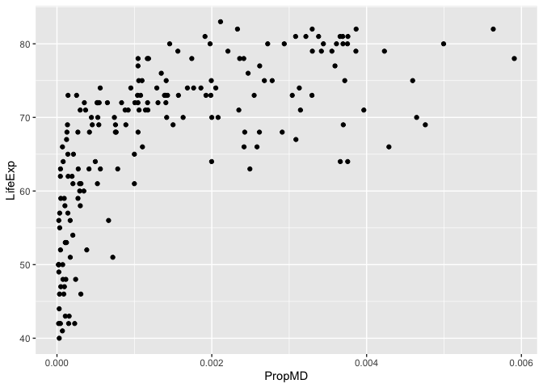

```r
df1 <- df %>% filter(PropMD < 0.03)

ggplot(df1, aes(x=PropMD, y=LifeExp)) + geom_point()
```

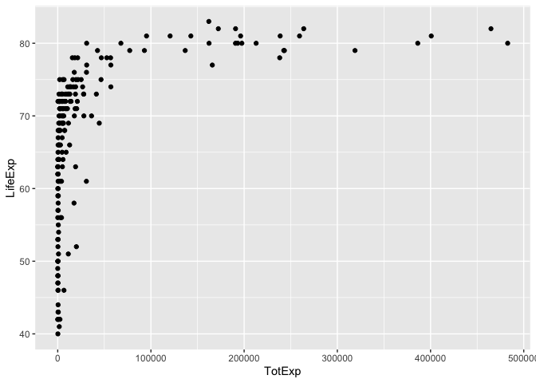

```r
ggplot(df1, aes(x=TotExp, y=LifeExp)) + geom_point()
```

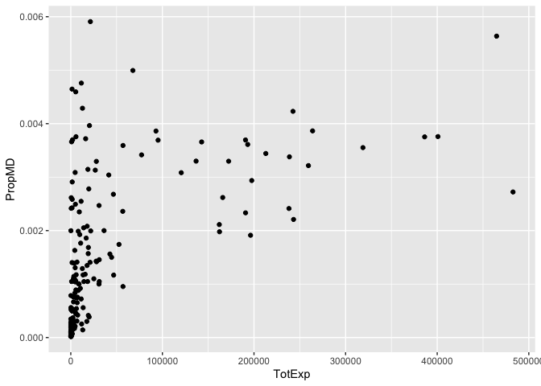

```r
ggplot(df1, aes(x=TotExp, y=PropMD)) + geom_point()
```

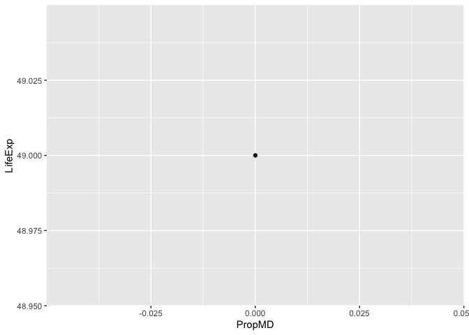

```r
df1 <- df %>% filter(TotExp < 50)

ggplot(df1, aes(x=PropMD, y=LifeExp)) + geom_point()
```

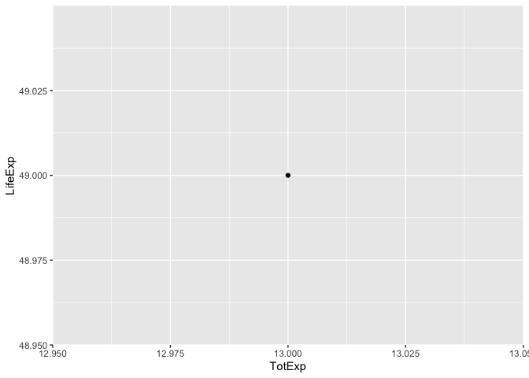

```r
ggplot(df1, aes(x=TotExp, y=LifeExp)) + geom_point()
```

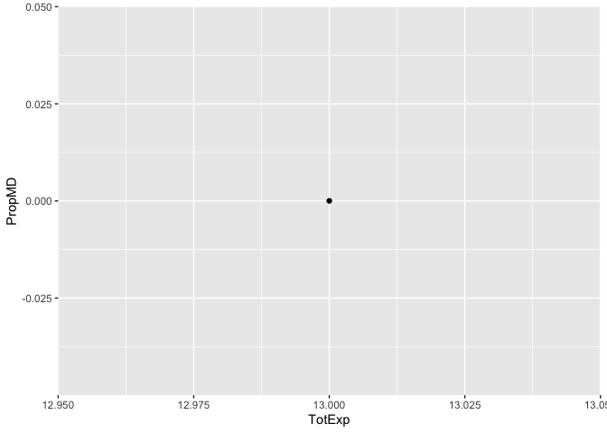

```r
ggplot(df1, aes(x=TotExp, y=PropMD)) + geom_point()
```

*Please show your work using an R-markdown document. Please name your assignment submission with your first initial and last name.*